# Data Pipeline — Beirne & Sugandi (2023) Replication (Japan)

## Visualizing the Descriptive Statistics

### Distributional shifts after 2021

Overlaid densities show how each variable's distribution changed between the paper period and the extended sample. The vertical dashed line marks the full-sample mean. A rightward or leftward shift in the extended period's density relative to the paper period indicates a change in the central tendency of that variable, while a wider or narrower spread indicates a change in dispersion.

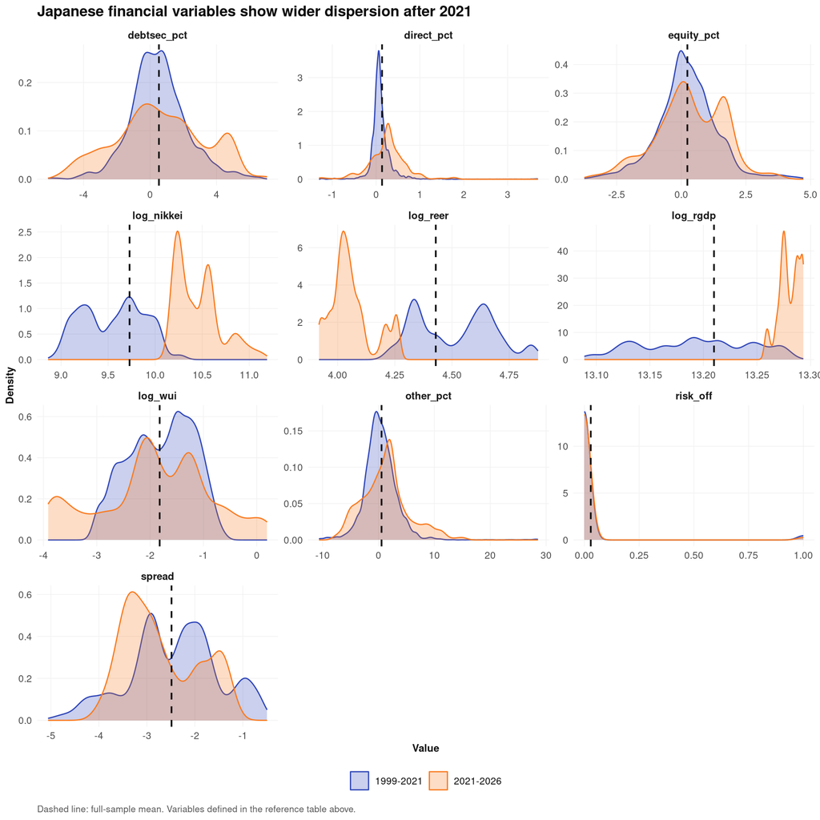

```r
plot_data <- final_dataset |>
  select(-date) |>
  pivot_longer(-period, names_to = "variable", values_to = "value") |>
  filter(!is.na(value))

plot_data$period <- factor(plot_data$period,
  levels = c("1999-2021", "2021-2026", "Full Sample"))

full_means <- final_dataset |>
  select(-date, -period) |>
  pivot_longer(everything(), names_to = "variable", values_to = "value") |>
  filter(!is.na(value)) |>
  group_by(variable) |>
  summarise(full_mean = mean(value, na.rm = TRUE), .groups = "drop")

plot_data <- plot_data |> left_join(full_means, by = "variable")

ggplot(plot_data, aes(x = value, fill = period, color = period)) +
  geom_density(alpha = 0.25, linewidth = 0.5) +
  geom_vline(data = full_means, aes(xintercept = full_mean),
    color = "#0D0D0D", linewidth = 0.7, linetype = "dashed") +
  facet_wrap(~variable, scales = "free", ncol = 3) +
  scale_fill_manual(values = period_colors) +
  scale_color_manual(values = period_colors) +
  labs(x = "Value", y = "Density", fill = NULL, color = NULL,
       title = "Japanese financial variables show wider dispersion after 2021",
       caption = "Dashed line: full-sample mean. Variables defined in the reference table above.") +
  theme_quant()
```

### Full-sample distributions

A single density curve for each variable pooling all observations from 1999 to 2026.

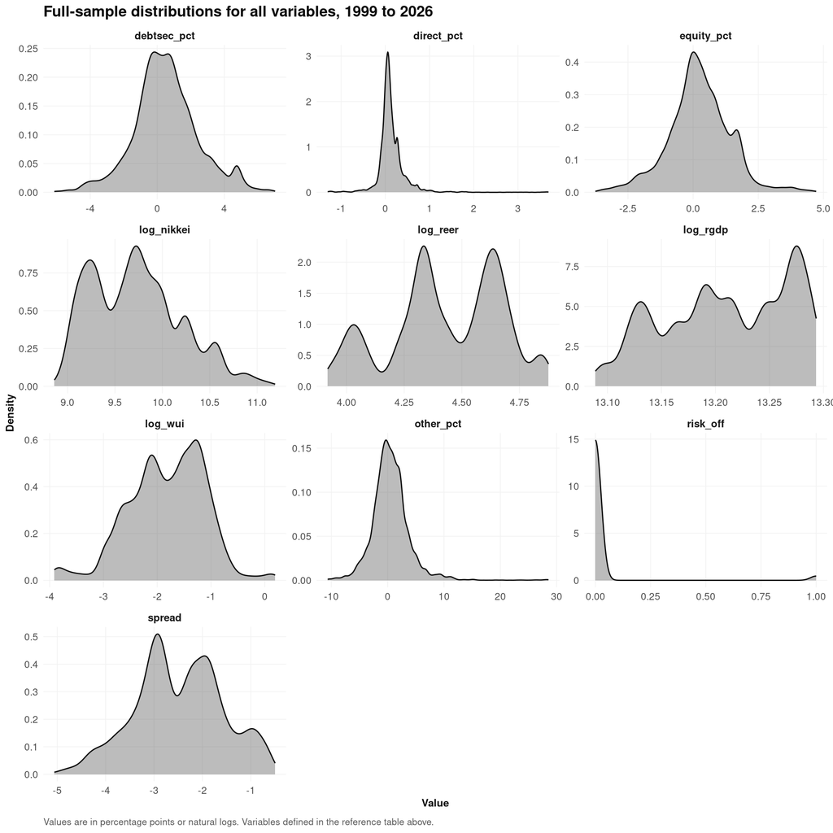

```r
full_dens <- final_dataset |>
  select(-date, -period) |>
  pivot_longer(everything(), names_to = "variable", values_to = "value") |>
  filter(!is.na(value))

ggplot(full_dens, aes(x = value)) +
  geom_density(fill = "#595959", color = "#0D0D0D", alpha = 0.4, linewidth = 0.5) +
  facet_wrap(~variable, scales = "free", ncol = 3) +
  labs(x = "Value", y = "Density",
       title = "Full-sample distributions for all variables, 1999 to 2026",
       caption = "Values are in percentage points or natural logs. Variables defined in the reference table above.") +
  theme_quant()
```

### Structural breaks in the extended sample

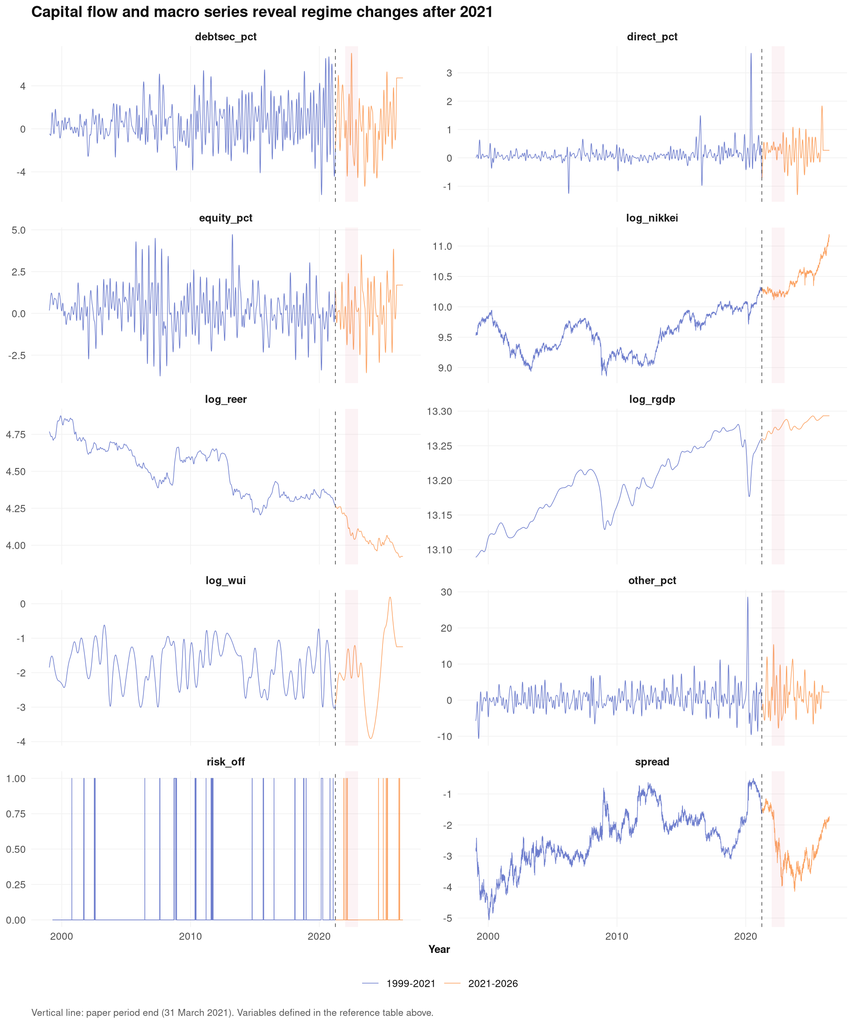

```r
ts_data <- final_dataset |>
  select(date, period, risk_off, spread, log_nikkei, log_reer, log_rgdp,
         log_wui, debtsec_pct, equity_pct, other_pct, direct_pct) |>
  pivot_longer(-c(date, period), names_to = "variable", values_to = "value") |>
  filter(!is.na(value))

paper_end <- as.Date("2021-03-31")

ggplot(ts_data, aes(x = date, y = value)) +
  geom_line(aes(color = period), linewidth = 0.25, alpha = 0.7) +
  geom_vline(xintercept = paper_end, linetype = "dashed",
             color = "#595959", linewidth = 0.3) +
  annotate("rect", xmin = as.Date("2022-01-01"), xmax = as.Date("2023-01-01"),
           ymin = -Inf, ymax = Inf, alpha = 0.05, fill = "#C91D42") +
  facet_wrap(~variable, scales = "free_y", ncol = 2) +
  scale_color_manual(values = period_colors) +
  labs(x = "Year", y = NULL, color = NULL,
       title = "Capital flow and macro series reveal regime changes after 2021",
       caption = "Vertical line: paper period end (31 March 2021). Variables defined in the reference table above.") +
  theme_quant() + coord_cartesian(xlim = c(as.Date("1999-01-01"), as.Date("2026-06-30")))
```

### Cross-variable correlations

The correlation matrix provides a diagnostic view of the relationships among the ten endogenous variables over the full sample. Of particular interest is the sign and magnitude of correlations involving the Risk-off indicator, which functions as the exogenous shock variable in the structural VAR.

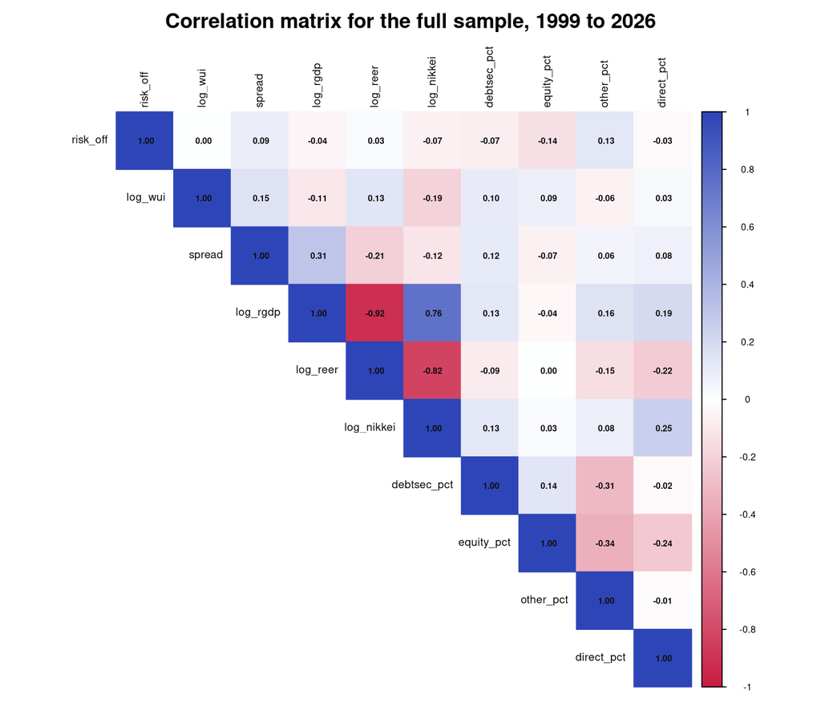

```r
library(corrplot)

cor_data <- final_dataset |>
  select(-date, -period)

cor_matrix <- cor(cor_data, use = "pairwise.complete.obs")

corrplot(cor_matrix, method = "color", type = "upper",
  tl.col = "#0D0D0D", tl.cex = 0.65,
  col = colorRampPalette(c("#C91D42", "#FFFFFF", "#2E45B8"))(200),
  addCoef.col = "#0D0D0D", number.cex = 0.5,
  cl.cex = 0.55, mar = c(1, 0, 2, 0),
  title = "Correlation matrix for the full sample, 1999 to 2026")
```

```r
system2("Rscript", c("scripts/generate_descriptive_table.R"))
system2("Rscript", c("scripts/generate_risk_off_table.R"))
```